# Assignment 4

## 3.1. The following code uses tidyverse syntax to generate some summary statistics about each class of cars. Use the data to recreate the plot below:

```r
stat_class = mpg %>%
  group_by(class) %>%
  summarize(avg_hwy = mean(hwy))
```

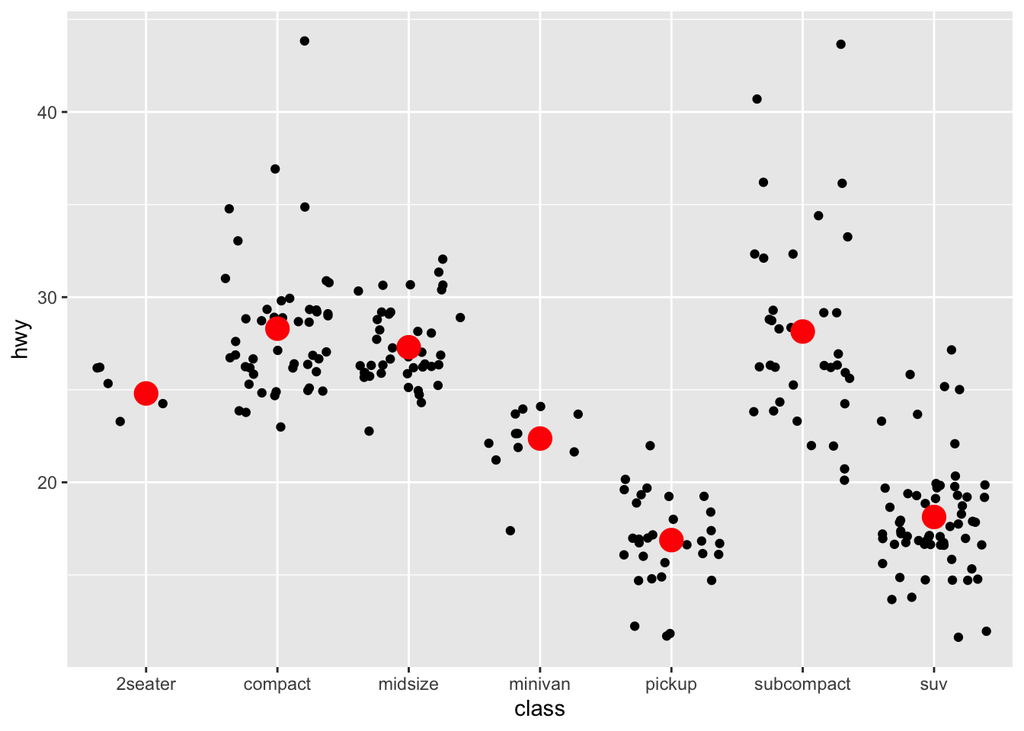

```r
ggplot(data = mpg, aes(x = class, y = hwy)) + geom_jitter() +
  geom_point(data = stat_class, aes(x = class, y = avg_hwy), shape = 19, color = "red", size = 5)
```

## 3.2. Simplify the following plot specifications:

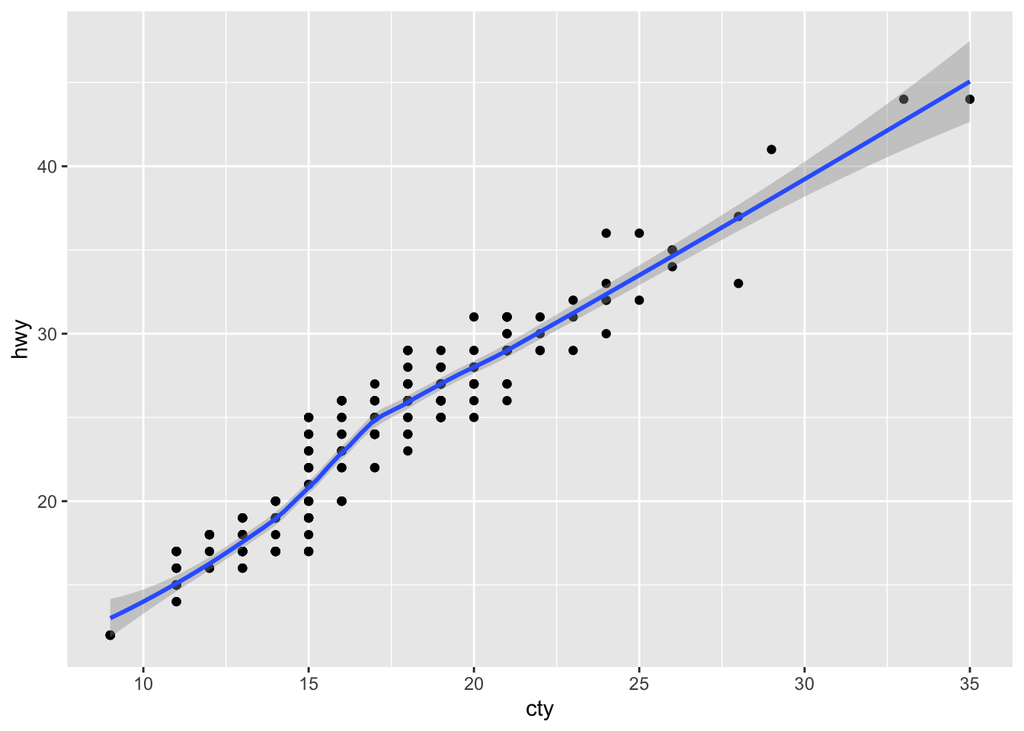

```r
ggplot() +
  geom_point(aes(y = hwy, x = cty), data = mpg) +
  geom_smooth(data = mpg, mapping = aes(x = cty, y = hwy))
```

The code above can be simplified using the code below:

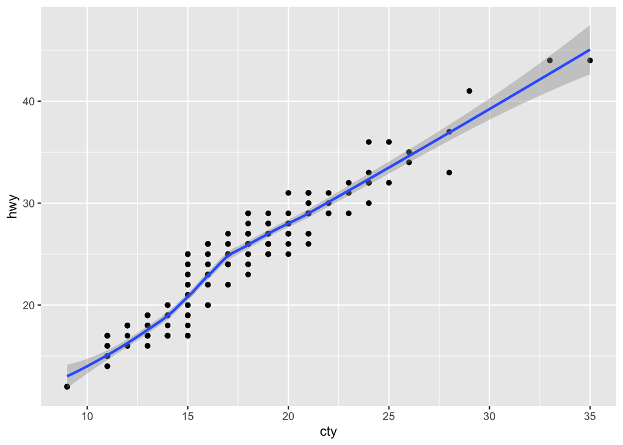

```r
ggplot(data = mpg, aes(x = cty, y = hwy)) + geom_point() + geom_smooth()
```

## 4. What does the following code do? Does it work? Does it make any sense? Why/why not?

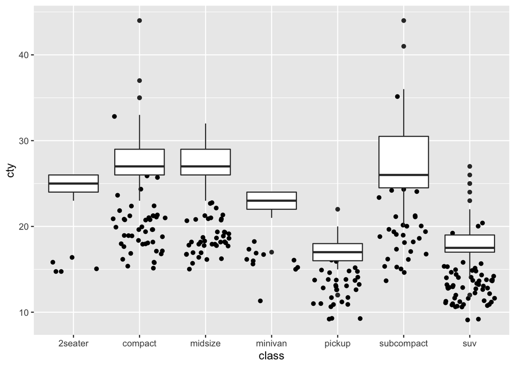

```r
ggplot(mpg) +
  geom_point(aes(class, cty), position = "jitter") +
  geom_boxplot(aes(class, hwy))
```

The plot produced above is made of 2 layers: - the first layer is a scatterplot which illustrates the relationship between class and cty. The data points for each variable under class have been “jittered” so that is easier to distinguish the cty value of each individual point.  
- the second layer is a boxplot illustrating the relationship between class and hwy variables. For each class, a boxplot is drawn to show the distribution of the hwy values within each class.

By overlaying both plots against each other, however, the combined plot will not make sense because the vertical axis of the overall plot only indicates the cty variable and not the hwy variable (for the boxplot). Moreover, this will provide confusion for readers not familiar with ggplot2 as they may visually misinterpret that there are many outliers within the boxplot, which will not make sense theoretically.

## 5. Download the ggplot2 cheatsheet from https://www.rstudio.com/resources/cheatsheets/ so you have a handy visual reference for all the geoms. For each of the plots below, identify in words the geom(s) used to draw it.

### Plot 1: geom_point() + scale_size()

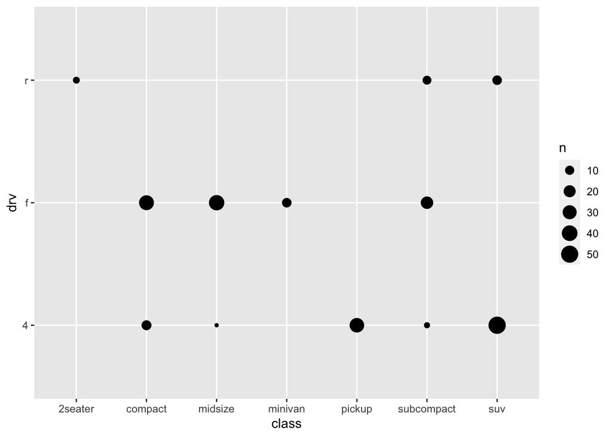

```r
plot1 = mpg %>%
  count(class, drv)

ggplot(data = plot1, aes(x = class, y = drv, size = n)) +
  geom_point() + scale_size()
```

### Plot 2: geom_hex() + scale_fill_gradient()

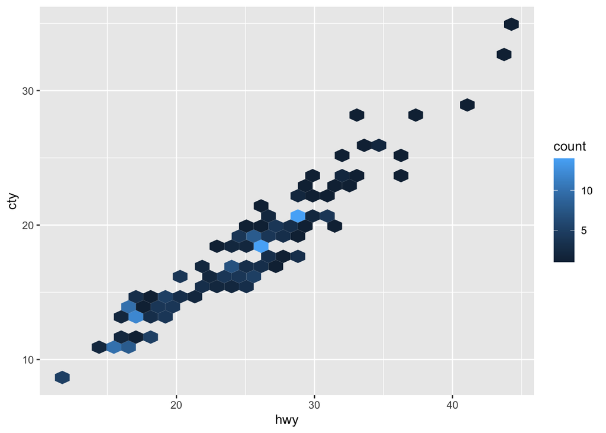

```r
ggplot(data = mpg, aes(x = hwy, y = cty)) +
  geom_hex()+
  scale_fill_gradient()
```

### Plot 3: geom_violin()

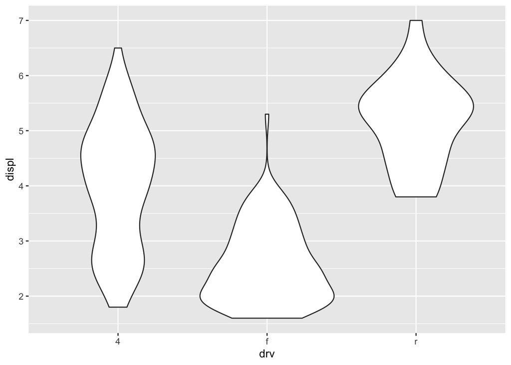

```r
ggplot(data = mpg, aes(x = drv, y = displ)) +
  geom_violin()
```

### Plot 4: geom_area()

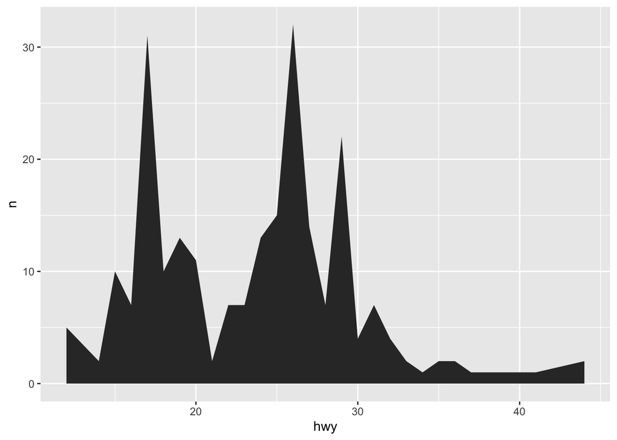

```r
plot4 = mpg %>%
  count(hwy)

ggplot(data = plot4, aes(x = hwy, y = n))+
  geom_area()
```

### Plot 5: geom_label()

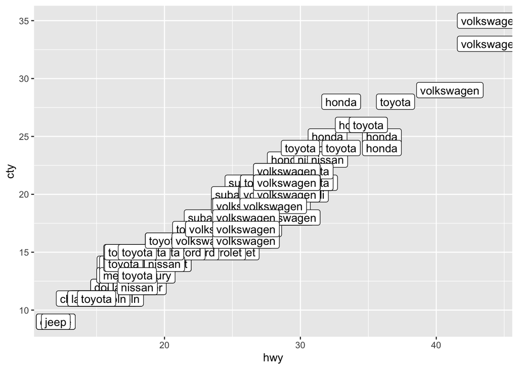

```r
ggplot(data = mpg, aes(x = hwy, y = cty)) +
  geom_label(aes(label = manufacturer))
```

### Plot 6: geom_rug() + geom_point()

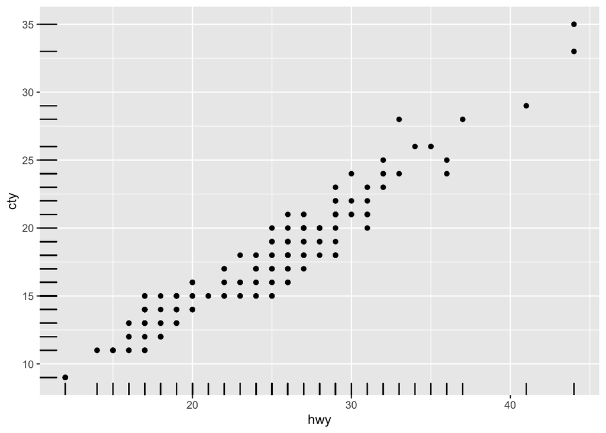

```r
ggplot(data = mpg, aes(x = hwy, y = cty)) +
  geom_rug()+
  geom_point()
```

# Question 2. Revisit nycflights13 using ggplot2

In this question, we revisit flights dataset from the nycflights13 package. Recall that it contains all flights that departed NYC (from three airports, JFK, LGA, and EWR) in 2013.

## 1. Explain (in words) what the following code does.

```r
df = flights %>%
  filter(origin == "JFK") %>%
  group_by(tailnum) %>%
  summarize(count = n(),
            dist = mean(distance, na.rm = TRUE),
            delay = mean(arr_delay, na.rm = TRUE)) %>%
  filter(count > 20, dist < 2000)
```

## 2. Use the df data frame in part 1 to recreate the following graph using ggplot2. Describes (in words) the trend(s) you observe from the graph.

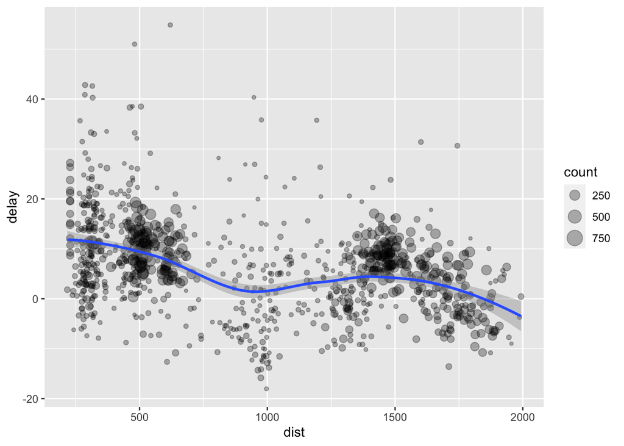

```r
ggplot(data = df, aes(x = dist,y = delay)) +
  geom_point(aes(size = count), alpha = 0.3) +
  geom_smooth()
```

# Question 3. HDB resale prices in Singapore

In this question, we want to replicate some findings from a Straits Times article on January 6, 2022, titled “Record 261 million-dollar HDB flats in 2021; resale prices rise in December as volume dips”.

Download the raw data directly from the website: https://data.gov.sg/dataset/resale-flat-prices

After that, unzip the downloaded file and import the following CSV into R: resale-flat-prices-based-on-registration-date-from-jan-2017-onwards.csv

Use this dataset to verify the following statements from the ST article. In your answer, simply state whether each statement is true or false. If the statement is not correct, provide the right number from your analysis.

```r
#load dataset
resale = read_csv("resale-flat-prices-based-on-registration-date-from-jan-2017-onwards.csv")
```

## 1. The total number of million-dollar HDB flats was 261 for the whole year of 2021.

```r
q1 = resale %>%
  mutate(year = substr(month, 1, 4))

q1a = q1 %>%
  filter(resale_price>=1000000) %>%
  group_by(year) %>%
  summarise(count = n())
```

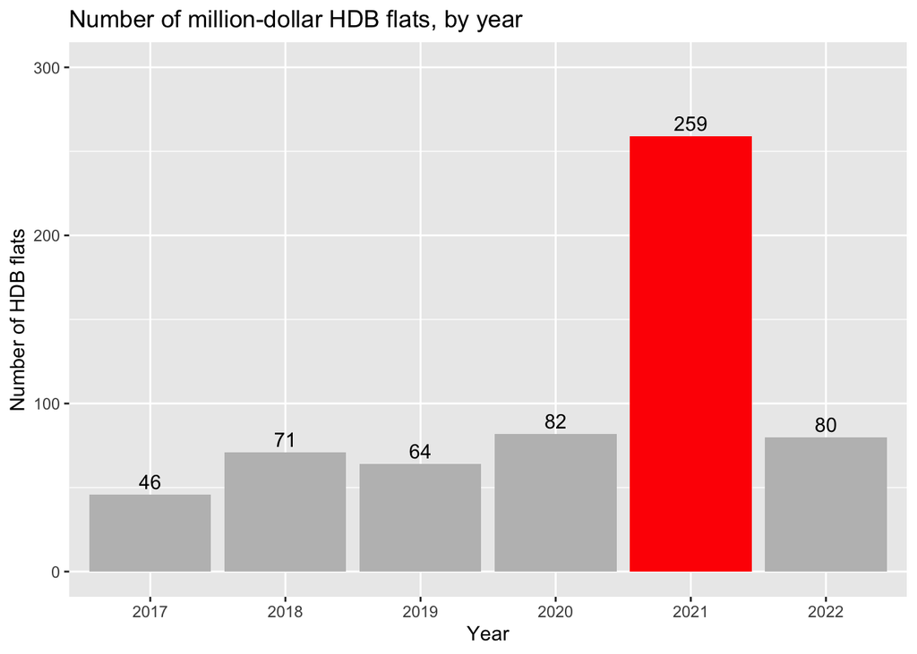

```r
ggplot(data = q1a, aes(x = year, y = count, fill = year)) +
  geom_bar(stat = "identity", show.legend = FALSE) +
  scale_fill_manual(values = c("grey", "grey", "grey", "grey", "red", "grey")) +
  geom_text(aes(label = count), vjust = -0.4) +
  ylim(0,300) +
  ggtitle("Number of million-dollar HDB flats, by year") +
  xlab("Year") + ylab("Number of HDB flats")
```

Based on the plot above, the above statement is false. In 2021, there were only 259 million-dollar (resale_value >= 1000000) HDB flats.

## 2. HDB resale prices rose 0.8 per cent in December 2021 from the previous month.

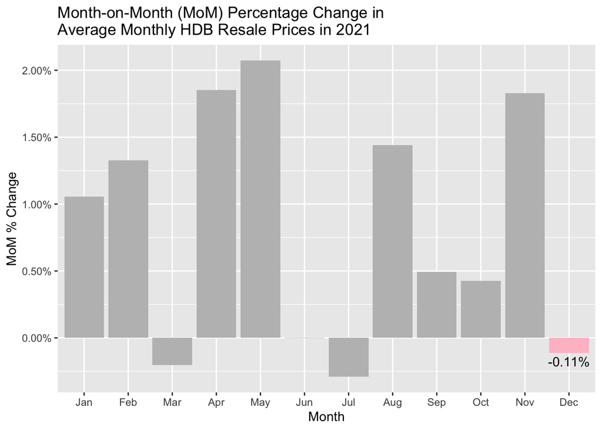

```r
options(scipen = 999) #turn off scientific notation

q2 = resale %>%
  group_by(month) %>%
  summarise(avg_month_price = mean(resale_price)) %>%
  mutate(mom_per_change = (avg_month_price - lag(avg_month_price))/lag(avg_month_price)) #column for MoM % change

q2a = q2[grep("2021", q2$month),] #subset data to include observations for year 2021 only

ggplot(data = q2a, aes(x = month, y = mom_per_change, fill = month)) +
  geom_col(show.legend = FALSE) +
  scale_y_continuous(labels = scales::percent) +
  geom_text(data = subset(q2a, month == "2021-12"),
            aes(label = scales::percent(mom_per_change, accuracy = 0.01L)),
            vjust = 1.4)+
  scale_x_discrete(labels = c("Jan", "Feb", "Mar", "Apr", "May", "Jun", "Jul", "Aug", "Sep", "Oct", "Nov", "Dec"))+
  scale_fill_manual(values = c("grey", "grey", "grey", "grey", "grey", "grey", "grey", "grey", "grey", "grey", "grey", "pink")) +
  ggtitle("Month-on-Month (MoM) Percentage Change in \nAverage Monthly HDB Resale Prices in 2021") +
  xlab("Month") + ylab("MoM % Change")
```

Based on the plot above, the statement is false. On average, HDB resale prices fell by 0.11% in December 2021 from the previous month.

## 3. HDB resale prices in December 2021 were 13.6 percent higher than a year ago.

[figure not shown]

```r
q3 = resale %>%
  group_by(month) %>%
  summarise(avg_month_price = mean(resale_price))

q3a = subset(q3, endsWith(month, "-12")) #subset q3 dataset using Dec values only across the years between 2017 and 2021

q3b = q3a %>%
  mutate(yoy_per_change = (avg_month_price - lag(avg_month_price))/lag(avg_month_price)) #column for YoY % change, using Dec values only

ggplot(data = q3b, aes(x = month, y = yoy_per_change, fill = month)) +
  geom_col(show.legend = FALSE) +
  scale_y_continuous(labels = scales::percent) +
  geom_text(data = subset(q3b, month == "2021-12"),
            aes(label = scales::percent(yoy_per_change, accuracy = 0.01L)),
            vjust = -0.5)+
  scale_fill_manual(values = c( "grey", "grey", "grey", "green")) +
  scale_x_discrete(labels = c("Dec 2017", "Dec 2018", "Dec 2019", "Dec 2020", "Dec 2021")) +
  xlab("Month") + ylab("YoY % Change") +
  ggtitle("Year-on-Year (YoY) Percentage Change in \nAverage HDB Resale Prices in December")
```

Based on the plot above, the statement is false. On average, HDB resale prices only increased by 10.3% in December 2021, compared to the previous year (December 2020).

## 4. There were 2,587 HDB flats sold in November 2021.

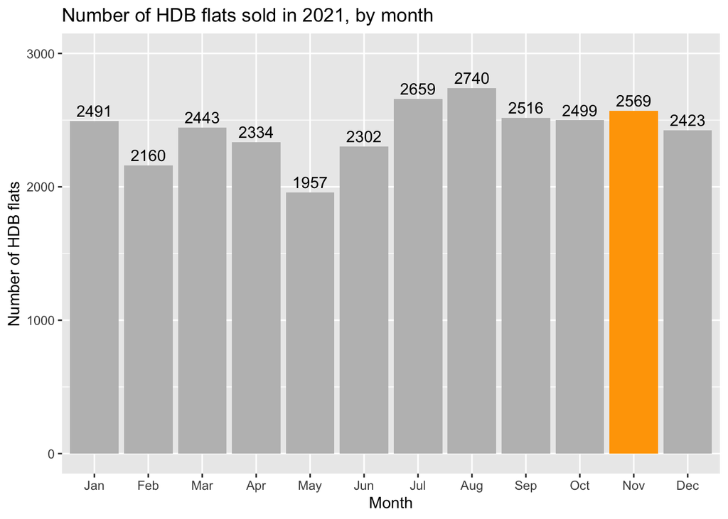

```r
q4 = subset(q1, year == "2021") #df for transactions in 2021 only

q4a = q4 %>%
  count(month) #count based on month

ggplot(data = q4a, aes(x = month, y = n, fill = month)) +
  geom_bar(stat = "identity", show.legend = FALSE) +
  scale_fill_manual(values = c("grey", "grey", "grey", "grey", "grey", "grey", "grey", "grey", "grey", "grey", "orange", "grey")) +
  geom_text(aes(label = n), vjust = -0.4) +
  ylim(0,3000) +
  ggtitle("Number of HDB flats sold in 2021, by month") +
  xlab("Month") + ylab("Number of HDB flats") +
  scale_x_discrete(labels = c("Jan", "Feb", "Mar", "Apr", "May", "Jun", "Jul", "Aug", "Sep", "Oct", "Nov", "Dec"))
```

Based on the plot above, the statement is false. Only 2569 HDB flats were sold in November 2021.